# **Bellabeat Data Analysis**

Sathyam A

2023-10-06

# Ask

💡 BUSINESS TASK: Analyze Fitbit data to gain insight and help guide marketing strategy for Bellabeat to grow as a global player.

- **Primary Stakeholders :**
1. Urška Sršen : Bellabeat’s co founder and Chief Creative Officer
2. Sando Mur: Mathematician and Bellabeat’s co founder; key member of the Bellabeat executive team
- **Secondary Stakeholders :** Marketing Analyst team

# Prepare

This is the FitBit Fitness Tracker Data data which is stored on Kaggle click here

This data set contains multiple CSV files which gives us useful information about the 30 users. The data also follows the ROCCC approach in some extent. *Reliability* , *Original* , *Comprehensive* , *Current* , *Cited*

**Reliability :** The data is from 30 FitBit users who consented to the submission of personal tracker data and generated by from a distributed survey

**Comprehensive :** Thirty eligible Fitbit users consented to the submission of personal tracker data, including minute-level output for physical activity, heart rate, and sleep monitoring.

**Cited :** The third-party data set was available by Mobius via Kaggle

*Now we have to import the data for the further analysis* * We begin with importing the necessary packages

```r
library(tidyverse)
```

```r
library(dplyr)
library(ggplot2)

library(skimr)
library(plotly)
library(geosphere)
```

- Now we import the data on which we need to do the analysis

```r
daily_activity <- read.csv("C:\\Users\\Admin\\Desktop\\Fitabase Data 4.12.16-5.12.16\\dailyActivity_merged.csv")
```

```r
daily_calories <- read.csv("C:\\Users\\Admin\\Desktop\\Fitabase Data 4.12.16-5.12.16\\dailyCalories_merged.csv")
```

```r
daily_intensities <- read.csv("C:\\Users\\Admin\\Desktop\\Fitabase Data 4.12.16-5.12.16\\dailyIntensities_merged.csv")
```

```r
daily_steps <- read.csv("C:\\Users\\Admin\\Desktop\\Fitabase Data 4.12.16-5.12.16\\dailySteps_merged.csv")
```

```r
sleep_day <- read.csv("C:\\Users\\Admin\\Desktop\\Fitabase Data 4.12.16-5.12.16\\sleepDay_merged.csv")
```

```r
weight_log_info <- read.csv("C:\\Users\\Admin\\Desktop\\Fitabase Data 4.12.16-5.12.16\\weightLogInfo_merged.csv")
```

```r
heart_rate_seconds <- read.csv("C:\\Users\\Admin\\Desktop\\Fitabase Data 4.12.16-5.12.16\\heartrate_seconds_merged.csv")
```

# Process

Here, we will explore the data frames to find area of commonalities and confirm that the data were appropriately imported. Functions like head(), colnames() glimpse() and str() will be used.

```r
head(daily_activity)
```

```
##           Id ActivityDate TotalSteps TotalDistance TrackerDistance
## 1 1503960366    4/12/2016      13162          8.50            8.50
## 2 1503960366    4/13/2016      10735          6.97            6.97
## 3 1503960366    4/14/2016      10460          6.74            6.74
## 4 1503960366    4/15/2016       9762          6.28            6.28
## 5 1503960366    4/16/2016      12669          8.16            8.16
## 6 1503960366    4/17/2016       9705          6.48            6.48
##   LoggedActivitiesDistance VeryActiveDistance ModeratelyActiveDistance
## 1                        0               1.88                     0.55
## 2                        0               1.57                     0.69
## 3                        0               2.44                     0.40
## 4                        0               2.14                     1.26
## 5                        0               2.71                     0.41
## 6                        0               3.19                     0.78
##   LightActiveDistance SedentaryActiveDistance VeryActiveMinutes
## 1                6.06                       0                25
## 2                4.71                       0                21
## 3                3.91                       0                30
## 4                2.83                       0                29
## 5                5.04                       0                36
## 6                2.51                       0                38
##   FairlyActiveMinutes LightlyActiveMinutes SedentaryMinutes Calories
## 1                  13                  328              728     1985
## 2                  19                  217              776     1797
## 3                  11                  181             1218     1776
## 4                  34                  209              726     1745
## 5                  10                  221              773     1863
## 6                  20                  164              539     1728
```

```r
head(daily_calories)
```

```
##           Id ActivityDay Calories
## 1 1503960366   4/12/2016     1985
## 2 1503960366   4/13/2016     1797
## 3 1503960366   4/14/2016     1776
## 4 1503960366   4/15/2016     1745
## 5 1503960366   4/16/2016     1863
## 6 1503960366   4/17/2016     1728
```

```r
head(daily_intensities)
```

```
##           Id ActivityDay SedentaryMinutes LightlyActiveMinutes
## 1 1503960366   4/12/2016              728                  328
## 2 1503960366   4/13/2016              776                  217
## 3 1503960366   4/14/2016             1218                  181
## 4 1503960366   4/15/2016              726                  209
## 5 1503960366   4/16/2016              773                  221
## 6 1503960366   4/17/2016              539                  164
##   FairlyActiveMinutes VeryActiveMinutes SedentaryActiveDistance
## 1                  13                25                       0
## 2                  19                21                       0
## 3                  11                30                       0
## 4                  34                29                       0
## 5                  10                36                       0
## 6                  20                38                       0
##   LightActiveDistance ModeratelyActiveDistance VeryActiveDistance
## 1                6.06                     0.55               1.88
## 2                4.71                     0.69               1.57
## 3                3.91                     0.40               2.44
## 4                2.83                     1.26               2.14
## 5                5.04                     0.41               2.71
## 6                2.51                     0.78               3.19
```

```r
head(daily_steps)
```

```
##           Id ActivityDay StepTotal
## 1 1503960366   4/12/2016     13162
## 2 1503960366   4/13/2016     10735
## 3 1503960366   4/14/2016     10460
## 4 1503960366   4/15/2016      9762
## 5 1503960366   4/16/2016     12669
## 6 1503960366   4/17/2016      9705
```

```r
head(heart_rate_seconds)
```

```
##           Id                 Time Value
## 1 2022484408 4/12/2016 7:21:00 AM    97
## 2 2022484408 4/12/2016 7:21:05 AM   102
## 3 2022484408 4/12/2016 7:21:10 AM   105
## 4 2022484408 4/12/2016 7:21:20 AM   103
## 5 2022484408 4/12/2016 7:21:25 AM   101
## 6 2022484408 4/12/2016 7:22:05 AM    95
```

```r
head(sleep_day)
```

```
##           Id              SleepDay TotalSleepRecords TotalMinutesAsleep
## 1 1503960366 4/12/2016 12:00:00 AM                 1                327
## 2 1503960366 4/13/2016 12:00:00 AM                 2                384
## 3 1503960366 4/15/2016 12:00:00 AM                 1                412
## 4 1503960366 4/16/2016 12:00:00 AM                 2                340
## 5 1503960366 4/17/2016 12:00:00 AM                 1                700
## 6 1503960366 4/19/2016 12:00:00 AM                 1                304
##   TotalTimeInBed
## 1            346
## 2            407
## 3            442
## 4            367
## 5            712
## 6            320
```

```r
head(weight_log_info)
```

```
##           Id                  Date WeightKg WeightPounds Fat   BMI
## 1 1503960366  5/2/2016 11:59:59 PM     52.6     115.9631  22 22.65
## 2 1503960366  5/3/2016 11:59:59 PM     52.6     115.9631  NA 22.65
## 3 1927972279  4/13/2016 1:08:52 AM    133.5     294.3171  NA 47.54
## 4 2873212765 4/21/2016 11:59:59 PM     56.7     125.0021  NA 21.45
## 5 2873212765 5/12/2016 11:59:59 PM     57.3     126.3249  NA 21.69
## 6 4319703577 4/17/2016 11:59:59 PM     72.4     159.6147  25 27.45
##   IsManualReport        LogId
## 1           True 1.462234e+12
## 2           True 1.462320e+12
## 3          False 1.460510e+12
## 4           True 1.461283e+12
## 5           True 1.463098e+12
## 6           True 1.460938e+12
```

# Analyze

We will use *skim_without_charts* for a broader overview of data frames

```r
skim_without_charts(daily_activity)
```

Data summary

| Name | daily_activity |
| --- | --- |
| Number of rows | 940 |
| Number of columns | 15 |
| _______________________ |  |
| Column type frequency: |  |
| character | 1 |
| numeric | 14 |
| ________________________ |  |
| Group variables | None |

**Variable type: character**

| skim_variable | n_missing | complete_rate | min | max | empty | n_unique | whitespace |
| --- | --- | --- | --- | --- | --- | --- | --- |
| ActivityDate | 0 | 1 | 8 | 9 | 0 | 31 | 0 |

**Variable type: numeric**

| skim_variable | n_missing | complete_rate | mean | sd | p0 | p25 | p50 | p75 | p100 |
| --- | --- | --- | --- | --- | --- | --- | --- | --- | --- |
| Id | 0 | 1 | 4.855407e+09 | 2.424805e+09 | 1503960366 | 2.320127e+09 | 4.445115e+09 | 6.962181e+09 | 8.877689e+09 |
| TotalSteps | 0 | 1 | 7.637910e+03 | 5.087150e+03 | 0 | 3.789750e+03 | 7.405500e+03 | 1.072700e+04 | 3.601900e+04 |
| TotalDistance | 0 | 1 | 5.490000e+00 | 3.920000e+00 | 0 | 2.620000e+00 | 5.240000e+00 | 7.710000e+00 | 2.803000e+01 |
| TrackerDistance | 0 | 1 | 5.480000e+00 | 3.910000e+00 | 0 | 2.620000e+00 | 5.240000e+00 | 7.710000e+00 | 2.803000e+01 |
| LoggedActivitiesDistance | 0 | 1 | 1.100000e-01 | 6.200000e-01 | 0 | 0.000000e+00 | 0.000000e+00 | 0.000000e+00 | 4.940000e+00 |
| VeryActiveDistance | 0 | 1 | 1.500000e+00 | 2.660000e+00 | 0 | 0.000000e+00 | 2.100000e-01 | 2.050000e+00 | 2.192000e+01 |
| ModeratelyActiveDistance | 0 | 1 | 5.700000e-01 | 8.800000e-01 | 0 | 0.000000e+00 | 2.400000e-01 | 8.000000e-01 | 6.480000e+00 |
| LightActiveDistance | 0 | 1 | 3.340000e+00 | 2.040000e+00 | 0 | 1.950000e+00 | 3.360000e+00 | 4.780000e+00 | 1.071000e+01 |
| SedentaryActiveDistance | 0 | 1 | 0.000000e+00 | 1.000000e-02 | 0 | 0.000000e+00 | 0.000000e+00 | 0.000000e+00 | 1.100000e-01 |
| VeryActiveMinutes | 0 | 1 | 2.116000e+01 | 3.284000e+01 | 0 | 0.000000e+00 | 4.000000e+00 | 3.200000e+01 | 2.100000e+02 |
| FairlyActiveMinutes | 0 | 1 | 1.356000e+01 | 1.999000e+01 | 0 | 0.000000e+00 | 6.000000e+00 | 1.900000e+01 | 1.430000e+02 |
| LightlyActiveMinutes | 0 | 1 | 1.928100e+02 | 1.091700e+02 | 0 | 1.270000e+02 | 1.990000e+02 | 2.640000e+02 | 5.180000e+02 |
| SedentaryMinutes | 0 | 1 | 9.912100e+02 | 3.012700e+02 | 0 | 7.297500e+02 | 1.057500e+03 | 1.229500e+03 | 1.440000e+03 |
| Calories | 0 | 1 | 2.303610e+03 | 7.181700e+02 | 0 | 1.828500e+03 | 2.134000e+03 | 2.793250e+03 | 4.900000e+03 |

```r
skim_without_charts(daily_calories)
```

Data summary

| Name | daily_calories |
| --- | --- |
| Number of rows | 940 |
| Number of columns | 3 |
| _______________________ |  |
| Column type frequency: |  |
| character | 1 |
| numeric | 2 |
| ________________________ |  |
| Group variables | None |

**Variable type: character**

| skim_variable | n_missing | complete_rate | min | max | empty | n_unique | whitespace |
| --- | --- | --- | --- | --- | --- | --- | --- |
| ActivityDay | 0 | 1 | 8 | 9 | 0 | 31 | 0 |

**Variable type: numeric**

| skim_variable | n_missing | complete_rate | mean | sd | p0 | p25 | p50 | p75 | p100 |
| --- | --- | --- | --- | --- | --- | --- | --- | --- | --- |
| Id | 0 | 1 | 4.855407e+09 | 2.424805e+09 | 1503960366 | 2320127002.0 | 4445114986 | 6.962181e+09 | 8877689391 |
| Calories | 0 | 1 | 2.303610e+03 | 7.181700e+02 | 0 | 1828.5 | 2134 | 2.793250e+03 | 4900 |

```r
skim_without_charts(daily_intensities)
```

Data summary

| Name | daily_intensities |
| --- | --- |
| Number of rows | 940 |
| Number of columns | 10 |
| _______________________ |  |
| Column type frequency: |  |
| character | 1 |
| numeric | 9 |
| ________________________ |  |
| Group variables | None |

**Variable type: character**

| skim_variable | n_missing | complete_rate | min | max | empty | n_unique | whitespace |
| --- | --- | --- | --- | --- | --- | --- | --- |
| ActivityDay | 0 | 1 | 8 | 9 | 0 | 31 | 0 |

**Variable type: numeric**

| skim_variable | n_missing | complete_rate | mean | sd | p0 | p25 | p50 | p75 | p100 |
| --- | --- | --- | --- | --- | --- | --- | --- | --- | --- |
| Id | 0 | 1 | 4.855407e+09 | 2.424805e+09 | 1503960366 | 2.320127e+09 | 4.445115e+09 | 6.962181e+09 | 8.877689e+09 |
| SedentaryMinutes | 0 | 1 | 9.912100e+02 | 3.012700e+02 | 0 | 7.297500e+02 | 1.057500e+03 | 1.229500e+03 | 1.440000e+03 |
| LightlyActiveMinutes | 0 | 1 | 1.928100e+02 | 1.091700e+02 | 0 | 1.270000e+02 | 1.990000e+02 | 2.640000e+02 | 5.180000e+02 |
| FairlyActiveMinutes | 0 | 1 | 1.356000e+01 | 1.999000e+01 | 0 | 0.000000e+00 | 6.000000e+00 | 1.900000e+01 | 1.430000e+02 |
| VeryActiveMinutes | 0 | 1 | 2.116000e+01 | 3.284000e+01 | 0 | 0.000000e+00 | 4.000000e+00 | 3.200000e+01 | 2.100000e+02 |
| SedentaryActiveDistance | 0 | 1 | 0.000000e+00 | 1.000000e-02 | 0 | 0.000000e+00 | 0.000000e+00 | 0.000000e+00 | 1.100000e-01 |
| LightActiveDistance | 0 | 1 | 3.340000e+00 | 2.040000e+00 | 0 | 1.950000e+00 | 3.360000e+00 | 4.780000e+00 | 1.071000e+01 |
| ModeratelyActiveDistance | 0 | 1 | 5.700000e-01 | 8.800000e-01 | 0 | 0.000000e+00 | 2.400000e-01 | 8.000000e-01 | 6.480000e+00 |
| VeryActiveDistance | 0 | 1 | 1.500000e+00 | 2.660000e+00 | 0 | 0.000000e+00 | 2.100000e-01 | 2.050000e+00 | 2.192000e+01 |

```r
skim_without_charts(daily_steps)
```

Data summary

| Name | daily_steps |
| --- | --- |
| Number of rows | 940 |
| Number of columns | 3 |
| _______________________ |  |
| Column type frequency: |  |
| character | 1 |
| numeric | 2 |
| ________________________ |  |
| Group variables | None |

**Variable type: character**

| skim_variable | n_missing | complete_rate | min | max | empty | n_unique | whitespace |
| --- | --- | --- | --- | --- | --- | --- | --- |
| ActivityDay | 0 | 1 | 8 | 9 | 0 | 31 | 0 |

**Variable type: numeric**

| skim_variable | n_missing | complete_rate | mean | sd | p0 | p25 | p50 | p75 | p100 |
| --- | --- | --- | --- | --- | --- | --- | --- | --- | --- |
| Id | 0 | 1 | 4.855407e+09 | 2.424805e+09 | 1503960366 | 2.320127e+09 | 4445114986.0 | 6962181067 | 8877689391 |
| StepTotal | 0 | 1 | 7.637910e+03 | 5.087150e+03 | 0 | 3.789750e+03 | 7405.5 | 10727 | 36019 |

```r
skim_without_charts(heart_rate_seconds)
```

Data summary

| Name | heart_rate_seconds |
| --- | --- |
| Number of rows | 2483658 |
| Number of columns | 3 |
| _______________________ |  |
| Column type frequency: |  |
| character | 1 |
| numeric | 2 |
| ________________________ |  |
| Group variables | None |

**Variable type: character**

| skim_variable | n_missing | complete_rate | min | max | empty | n_unique | whitespace |
| --- | --- | --- | --- | --- | --- | --- | --- |
| Time | 0 | 1 | 19 | 21 | 0 | 961274 | 0 |

**Variable type: numeric**

| skim_variable | n_missing | complete_rate | mean | sd | p0 | p25 | p50 | p75 | p100 |
| --- | --- | --- | --- | --- | --- | --- | --- | --- | --- |
| Id | 0 | 1 | 5.513765e+09 | 1950223761.0 | 2022484408 | 4388161847 | 5553957443 | 6962181067 | 8877689391 |
| Value | 0 | 1 | 7.733000e+01 | 19.4 | 36 | 63 | 73 | 88 | 203 |

```r
skim_without_charts(sleep_day)
```

Data summary

| Name | sleep_day |
| --- | --- |
| Number of rows | 413 |
| Number of columns | 5 |
| _______________________ |  |
| Column type frequency: |  |
| character | 1 |
| numeric | 4 |
| ________________________ |  |
| Group variables | None |

**Variable type: character**

| skim_variable | n_missing | complete_rate | min | max | empty | n_unique | whitespace |
| --- | --- | --- | --- | --- | --- | --- | --- |
| SleepDay | 0 | 1 | 20 | 21 | 0 | 31 | 0 |

**Variable type: numeric**

| skim_variable | n_missing | complete_rate | mean | sd | p0 | p25 | p50 | p75 | p100 |
| --- | --- | --- | --- | --- | --- | --- | --- | --- | --- |
| Id | 0 | 1 | 5.000979e+09 | 2.06036e+09 | 1503960366 | 3977333714 | 4702921684 | 6962181067 | 8792009665 |
| TotalSleepRecords | 0 | 1 | 1.120000e+00 | 3.50000e-01 | 1 | 1 | 1 | 1 | 3 |
| TotalMinutesAsleep | 0 | 1 | 4.194700e+02 | 1.18340e+02 | 58 | 361 | 433 | 490 | 796 |
| TotalTimeInBed | 0 | 1 | 4.586400e+02 | 1.27100e+02 | 61 | 403 | 463 | 526 | 961 |

- **Let’s analyze the average sleep time and average bed time**

```r
Avg_min_time <- sleep_day %>% summarize(avg_sleeptime = mean(TotalMinutesAsleep))
Avg_min_time
```

```
##   avg_sleeptime
## 1      419.4673
```

```r
Avg_bed_time <- sleep_day %>% summarize(avg_bedtime = mean(TotalTimeInBed))
Avg_bed_time
```

```
##   avg_bedtime
## 1    458.6392
```

*This analysis show that the user take almost 40 minutes to sleep when they go to the bed*

- We can see the **activity dates** here but there is not a clear understanding on seeing just the dates and hard to do the analysis , so let’s just change the format to days of the week(Monday - Sunday)

```r
daily_activity <- daily_activity %>%
  mutate(weekday1 = weekdays(as.Date(ActivityDate , "%m/%d/%Y")))

glimpse(daily_activity)
```

```
## Rows: 940
## Columns: 16
## $ Id                       <dbl> 1503960366, 1503960366, 1503960366, 150396036…
## $ ActivityDate             <chr> "4/12/2016", "4/13/2016", "4/14/2016", "4/15/…
## $ TotalSteps               <int> 13162, 10735, 10460, 9762, 12669, 9705, 13019…
## $ TotalDistance            <dbl> 8.50, 6.97, 6.74, 6.28, 8.16, 6.48, 8.59, 9.8…
## $ TrackerDistance          <dbl> 8.50, 6.97, 6.74, 6.28, 8.16, 6.48, 8.59, 9.8…
## $ LoggedActivitiesDistance <dbl> 0, 0, 0, 0, 0, 0, 0, 0, 0, 0, 0, 0, 0, 0, 0, …
## $ VeryActiveDistance       <dbl> 1.88, 1.57, 2.44, 2.14, 2.71, 3.19, 3.25, 3.5…
## $ ModeratelyActiveDistance <dbl> 0.55, 0.69, 0.40, 1.26, 0.41, 0.78, 0.64, 1.3…
## $ LightActiveDistance      <dbl> 6.06, 4.71, 3.91, 2.83, 5.04, 2.51, 4.71, 5.0…
## $ SedentaryActiveDistance  <dbl> 0, 0, 0, 0, 0, 0, 0, 0, 0, 0, 0, 0, 0, 0, 0, …
## $ VeryActiveMinutes        <int> 25, 21, 30, 29, 36, 38, 42, 50, 28, 19, 66, 4…
## $ FairlyActiveMinutes      <int> 13, 19, 11, 34, 10, 20, 16, 31, 12, 8, 27, 21…
## $ LightlyActiveMinutes     <int> 328, 217, 181, 209, 221, 164, 233, 264, 205, …
## $ SedentaryMinutes         <int> 728, 776, 1218, 726, 773, 539, 1149, 775, 818…
## $ Calories                 <int> 1985, 1797, 1776, 1745, 1863, 1728, 1921, 203…
## $ weekday1                 <chr> "Tuesday", "Wednesday", "Thursday", "Friday",…
```

Making them in order

```r
daily_activity$weekday1 <- ordered(daily_activity$weekday1, levels=c("Monday","Tuesday","Wednesday","Thursday","Friday","Saturday","Sunday"))
```

```r
activity_data <- daily_activity %>%
  group_by(weekday1) %>%
  summarize(count_of = n())

glimpse(activity_data)
```

```
## Rows: 7
## Columns: 2
## $ weekday1 <ord> Monday, Tuesday, Wednesday, Thursday, Friday, Saturday, Sunday
## $ count_of <int> 120, 152, 150, 147, 126, 124, 121
```

# Share

So we were told to analyze Fitbit data to gain insight and help guide marketing strategy for Bellabeat to grow as a global player , the part of the analyze is done and now comes the part of Sharing , which is through… **THE VISUALIZATON PART**

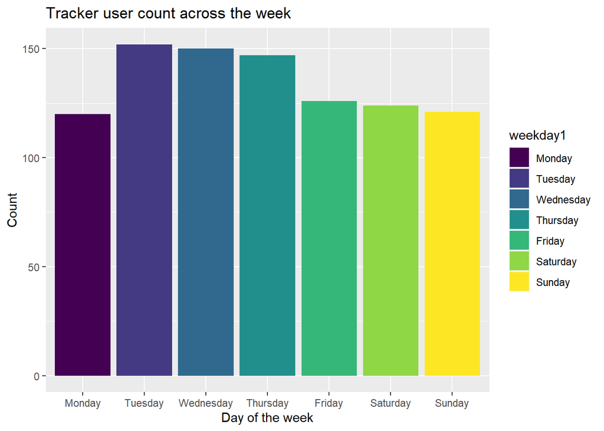

```r
ggplot(data = daily_activity) + geom_bar(mapping = aes(x = weekday1 , fill = weekday1)) +
  labs(title="Tracker user count across the week", x="Day of the week", y="Count")
```

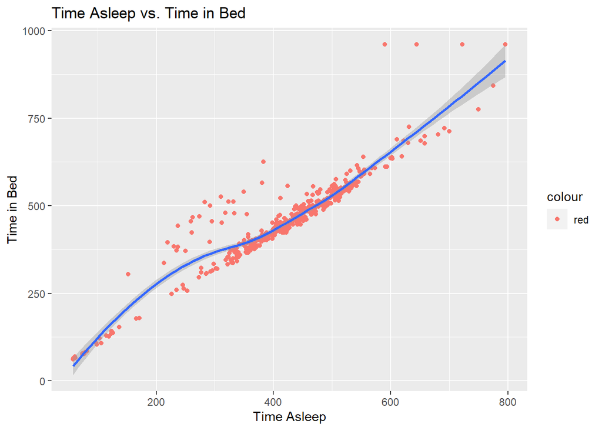

```r
ggplot(data = sleep_day) + geom_point(mapping =
                                       aes(x = TotalMinutesAsleep , y = TotalTimeInBed , color = "red"))+
  geom_smooth(mapping = aes(x = TotalMinutesAsleep , y = TotalTimeInBed))+
  labs(title="Time Asleep vs. Time in Bed",x="Time Asleep",y="Time in Bed")
```

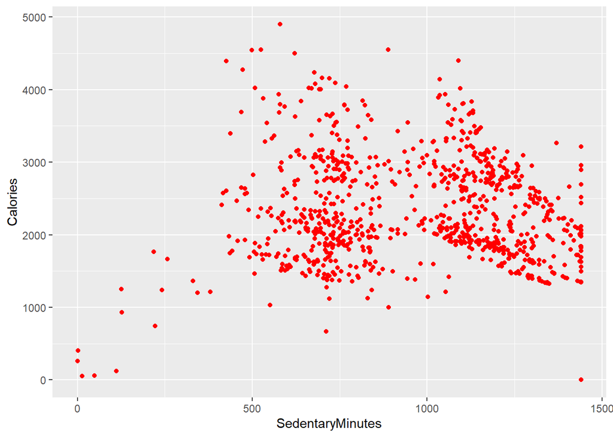

```r
plot1 <- ggplot(data = daily_activity) +
  geom_point(mapping = aes(x = SedentaryMinutes, y = Calories) ,  color ="red")

plot2 <- ggplot(data = daily_activity) +
  geom_point(mapping = aes(x = LightlyActiveMinutes, y = Calories) , color = "blue")

plot3 <- ggplot(data = daily_activity) +
  geom_point(mapping = aes(x = FairlyActiveMinutes , y = Calories) , color = "green")

plot4 <- ggplot(data = daily_activity) +
  geom_point(mapping = aes(x = VeryActiveMinutes , y = Calories) , color = "yellow")

# Set up a multi-plot layout
par(mfrow = c(2, 2))  # 2 rows and 2 columns

plot1
```

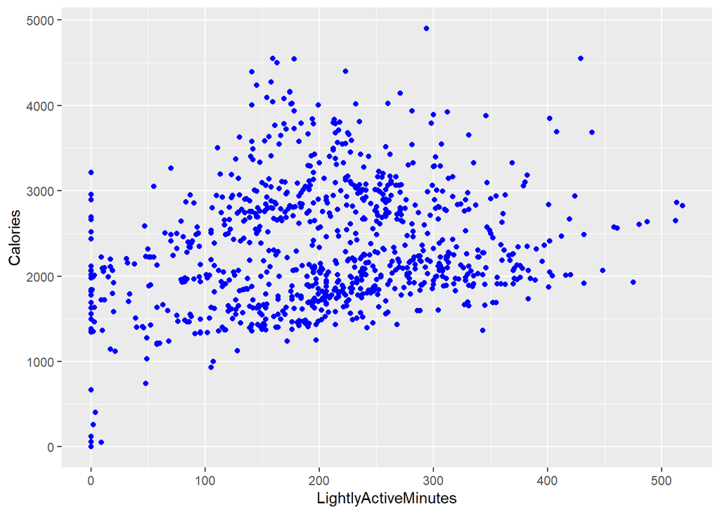

```r
plot2
```

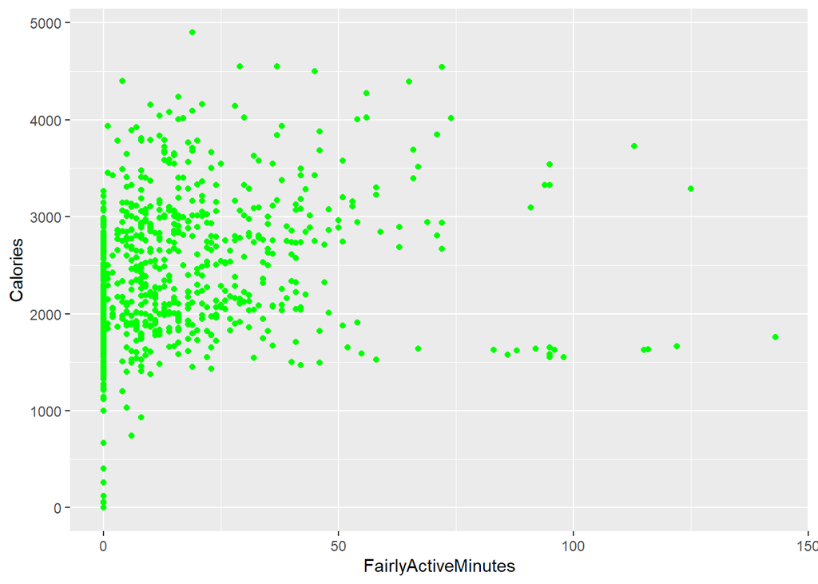

```r
plot3
```

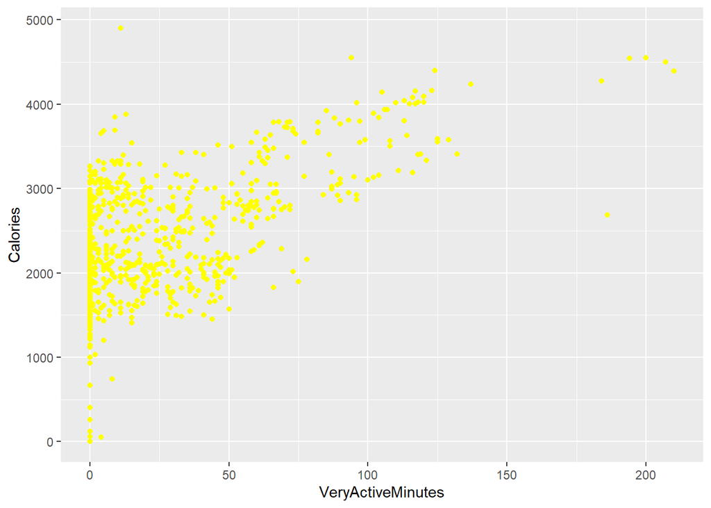

```r
plot4
```

# Act

## Recommendations

- Bellabeat can include function in Bellabeat app to alert user who tends to have a high number to sedentary minutes
- Bellabeat can include timely notification in Leaf/Time to motivate user to move around regularly to reduce their sedentary minutes
- The app should also encourage users to have time-outs for meditations and stress management routine like breathing exercises, yoga and mindful meditations.
- Finally, the app should encourage users to meet the recommended 10,000 steps and at least 7 hours of sleep daily
- The app should also have a chat channel for users to directly interact with health specialists or coaches for health counseling, nutrition and exercises where the need arises.
- Menstrual Health guidance to help note your symptoms throughout the cycle.

## Premium Membership and Offers

- *Free Bellabeat Device:* Offer a free Bellabeat device of their choice as a sign-up bonus when users join the membership program. This immediate gratification can be a strong incentive.
- *Yearly Subscription Discount:* Provide a significant discount for users who commit to a yearly membership upfront. This discount could be as much as 50% off the monthly rate.
- *Double Loyalty Points:* Reward members with double the loyalty points for every purchase, which can be redeemed for future Bellabeat products or accessories.
- *Members-Only Contests:* Organize exclusive contests or sweepstakes with valuable prizes, like all-expenses-paid wellness retreats or a year’s worth of Bellabeat product

## Bellabet Products

Bellabeat products are truly exceptional in their design and functionality. Their innovative approach to merging technology with wellness and beauty is both impressive and inspiring. Bellabeat products empower individuals to take control of their health and well-being with elegance and sophistication, making them a delightful addition to anyone’s lifestyle. Keep up the fantastic work, Bellabeat!